# Chapter 2 Lab

Allen Church

Load necessary packages

```r
library(haven)
```

Set working directory and load lab data

```r
lab <- read_dta("Ch2_lab_survey_data.dta")
```

1. Use the following to create dummy variables for Arlington and Prince William Counties. How many observations are from each county?

```r
#Create dummy variable for Arlington county, selecting corresponding precinct codes with OR operators
lab$Arlington <- (
  lab$precinct == "AR49" | lab$precinct == "AR22" | lab$precinct == "AR2" |
  lab$precinct == "AR18" | lab$precinct == "41" | lab$precinct == "16" |
  lab$precinct == "4" | lab$precinct == "17" | (lab$precinct == "2" &

lab$state == 4& !is.na(lab$state))|
  lab$precinct == "31" | lab$precinct == "48")

#Count observations from each county, in this case TRUE corresponds to Arlington
table(lab$Arlington)
```

```
##
## FALSE  TRUE
##  1884   475
```

```r
#Create dummy variable for Prince William county, selecting corresponding precinct codes with OR operators
lab$PrinceWilliam1 <- (
  lab$precinct == "PW 101" | lab$precinct == "PW 104" |  lab$precinct == "PW 401" | lab$precinct == "PW101" |
  lab$precinct == "PW104" | lab$precinct == "PW402" | lab$precinct == "PW406"  | lab$precinct == "401" | lab$precinct == "402" |
(lab$precinct == "104" & lab$state == 4)    )

#Count observations from each county, in this case TRUE corresponds to Prince William
table(lab$PrinceWilliam1)
```

```
##
## FALSE  TRUE
##  2171   188
```

2. Create dummy variables for each state/DC. How many observations are in DC, Maryland, Ohio and Virginia?

```r
#Create dummy variables for each state
lab$DC <- (lab$state == 1)
lab$Maryland <- (lab$state == 2)
lab$Ohio <- (lab$state == 3)
lab$Virginia <- (lab$state == 4)

#Tabulate observations for each state
table(lab$state)
```

```
##
##   1   2   3   4
## 768 369 547 664
```

3. Convert the year_born variable into age. Be sure to check for and correct for lab errors. What is the average age of all observations in the lab set? The minimum and maximum?

```r
#Since the survey was taken in 2016, subtract 2016 - year born to obtain age
#Create new age column
lab$age <- 2016 - lab$year_born

#The first summary of the age column shows there is a max age of 152 and 482 NA rows
summary(lab$age)
```

```
##    Min. 1st Qu.  Median    Mean 3rd Qu.    Max.    NA's
##   17.00   30.00   41.00   43.17   55.00  152.00     482
```

```r
#Subset the lab dataframe and exclude values where age is above 100
newdata <- subset(lab, age < 100)

#The summary of the newdata age column shows a new maximum of 95, which is possible
summary(newdata$age)
```

```
##    Min. 1st Qu.  Median    Mean 3rd Qu.    Max.
##   17.00   30.00   41.00   43.07   55.00   95.00
```

4. What is the distribution of the gender variable? Create a male dummy variable and indicate the distribution of this variable. Compare distribution of your male variable to the distribution of the gender variable.

```r
#Create male and female variables
lab$male <- (lab$gender == 1)
lab$female <- (lab$gender == 2)
```

Distribution of male variable

```r
table(lab$male)
```

```
##
## FALSE  TRUE
##  1067   886
```

Distribution of gender variable. The below table shows that 5 respondents did not identify with the binary gender definition

```r
table(lab$gender)
```

```
##
##    1    2    3
##  886 1062    5
```

5. Provide descriptive stats for Trump and Clinton feeling thermometer. Is there anything you need to adjust?

```r
#Summarize Clinton feeling thermometer, see there is a max of 200
summary(lab$therm_clinton)
```

```
##    Min. 1st Qu.  Median    Mean 3rd Qu.    Max.    NA's
##    0.00   20.00   70.00   57.12   90.00  200.00     231
```

```r
#Turn values over 100 into NA and summarize again
lab$therm_clinton[lab$therm_clinton > 100] <- NA
summary(lab$therm_clinton)
```

```
##    Min. 1st Qu.  Median    Mean 3rd Qu.    Max.    NA's
##    0.00   20.00   70.00   57.06   90.00  100.00     232
```

```r
#Summarize Trump feeling thermometer
summary(lab$therm_trump)
```

```
##    Min. 1st Qu.  Median    Mean 3rd Qu.    Max.    NA's
##    0.00    0.00    0.00   17.76   25.00  100.00     292
```

6. What is the distribution of the education variable? Is there any adjustment you would need to make if you will use this as a continuous variable in a regression model?

```r
#Below shows 7 values for education question
lab1 <- read_dta("Ch2_lab_survey_data.dta")
table(lab1$education)
```

```
##
##   1   2   3   4   5   6   7
##  17 125 245  11 134 677 746
```

```r
#Below we adjust education to exclude the Other response in answer 4, and re-assign the other responses accordingly
#Additionally, the Other response only had 11 values
lab1$education[lab1$education == 4] <- NA
lab1$education[lab1$education == 5] <- 4
lab1$education[lab1$education == 6] <- 5
lab1$education[lab1$education == 7] <- 6

#Generate a new summary table
table(lab1$education)
```

```
##
##   1   2   3   4   5   6
##  17 125 245 134 677 746
```

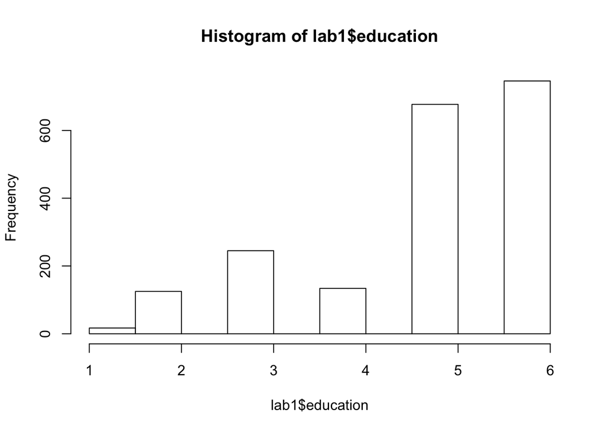

```r
#A quick histogram to show the distribution of education
#Below (as well as the table above) shows a low number of responses from 1 - Some high school, which could indicate a bias in sampling, or simply reflect the education of the sample.
hist(lab1$education)
```